# ST 495 HW9

Eric Warren

2022-11-03

## Honor Code

I have neither given nor received unauthorized assistance on this test or assignment. -**Eric Warren**

### Problem 1

#### Part A

Here we are going to load in the `HairEyeColor` data set. Convert the 3-way table into a data frame with 32 rows and 4 columns. Partition the data frame into two parts — one for male and one for female. For each gender, construct a stacked barplot of the frequencies with Hair color in the X-axis and Eye color in the Y-axis, with different eye colors as different stacks of the bars. Write down your interpretation of the plots.

```r
# Changing data into dataframe
library(tidyverse)
```

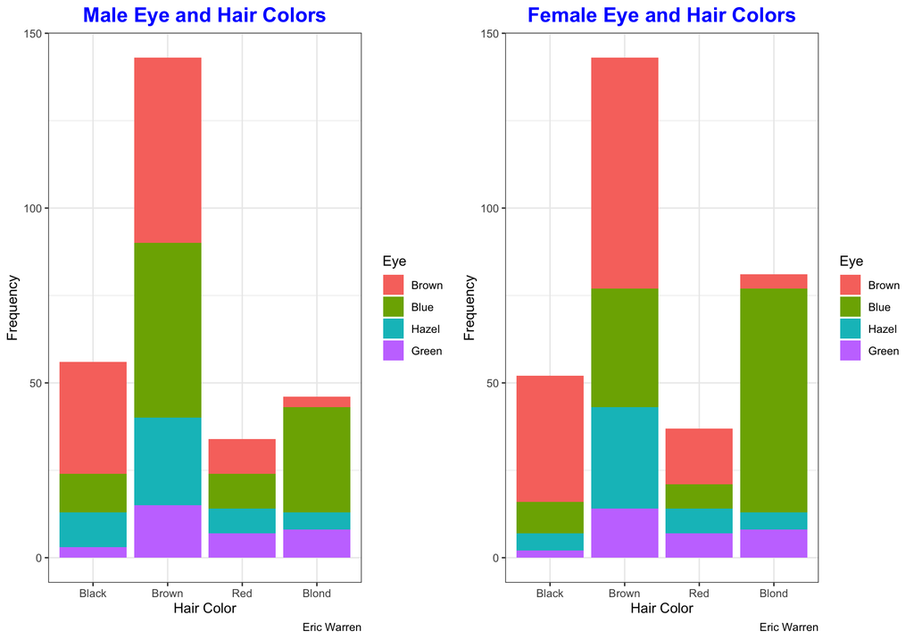

```r
hairEyeColor <- as.data.frame(ftable(HairEyeColor))

# Partition the data
male <- filter(hairEyeColor, Sex == "Male")
female <- filter(hairEyeColor, Sex != "Male")

# Making a stacked barplot of males and females side by side
library(gridExtra)
plot1 <- male %>%
  ggplot(aes(x = Hair, y = Freq, fill = Eye)) +
  geom_bar(stat = "identity") +
  theme_bw() +
  labs(title = "Male Eye and Hair Colors",
       caption = "Eric Warren",
       x = "Hair Color",
       y = "Frequency",
       color = "Eye Color") +
  theme_bw() +
  theme(plot.title = element_text(color = "blue",
                                  face = "bold",
                                  size = 16,
                                  hjust = 0.5))
plot2 <- female %>%
  ggplot(aes(x = Hair, y = Freq, fill = Eye)) +
  geom_bar(stat = "identity") +
  theme_bw() +
  labs(title = "Female Eye and Hair Colors",
       caption = "Eric Warren",
       x = "Hair Color",
       y = "Frequency",
       color = "Eye Color") +
  theme_bw() +
  theme(plot.title = element_text(color = "blue",
                                  face = "bold",
                                  size = 16,
                                  hjust = 0.5))
grid.arrange(plot1, plot2, ncol = 2)
```

As we can see from this plot, they are roughly the same except there are more blond hair, blue eye females than males. Also most blonds have blue eyes and most people with black hair have brown eyes. The other hair colors are toss ups and the hair color most prevalent is brown.

#### Part B

Now consider the original 3-way table. There are three features: Hair color, Eye color, and Sex. For each pair of features, carry out a chi-square test of independence and report whether there is an association between features.

```r
# Make our new 2 way tables
hairVsEye <- HairEyeColor[ , , 1] + HairEyeColor[ , , 2]
hairVsSex <- HairEyeColor[ , 1, ] + HairEyeColor[ , 2, ] + HairEyeColor[ , 3, ] + HairEyeColor[ , 4, ]
eyeVsSex <- HairEyeColor[ 1, , ] + HairEyeColor[2, , ] + HairEyeColor[3, , ] + HairEyeColor[4, , ]

# Do Chi Square Test to see if there is an association
chiTestHairVsSex <- chisq.test(hairVsSex)
chiTestHairVsSex
```

```
##
##  Pearson's Chi-squared test
##
## data:  hairVsSex
## X-squared = 7.9942, df = 3, p-value = 0.04613
```

```r
chiTestHairVsEye <- chisq.test(hairVsEye)
chiTestHairVsEye
```

```
##
##  Pearson's Chi-squared test
##
## data:  hairVsEye
## X-squared = 138.29, df = 9, p-value < 2.2e-16
```

```r
chiTestEyeVsSex <- chisq.test(eyeVsSex)
chiTestEyeVsSex
```

```
##
##  Pearson's Chi-squared test
##
## data:  eyeVsSex
## X-squared = 1.5298, df = 3, p-value = 0.6754
```

```r
traitsCMHTest <- mantelhaen.test(HairEyeColor)
traitsCMHTest # Making sure something has association
```

```
##
##  Cochran-Mantel-Haenszel test
##
## data:  HairEyeColor
## Cochran-Mantel-Haenszel M^2 = 140.28, df = 9, p-value < 2.2e-16
```

From our tests we know the null hypothesis is that there is no association between variables and from the alternative that there is association. The $\alpha$ level for these tests are 0.05.

- We can see from the Hair and Eye variables that the p-value from this test is 2.3252868^{-25}. From this result, we can reject the null hypothesis and there is an association between hair and eye colors.
- We can see from the Hair and Sex variables that the p-value from this test is 0.0461308. From this result, we can reject the null hypothesis and there is an association between hair color and a person’s sex.
- We can see from the Sex and Eye variables that the p-value from this test is 0.6754042. From this result, we can fail to reject the null hypothesis and conclude that there is most likely *NOT* an association between a person’s sex and eye color.
- Lastly, we can see from the Cochran-Mantel-Haenszel test that there was some kind of association with our variables when they were all together with the p-value of 9.016374^{-26}. We can see from before that the hair color is associated with the other two variables which causes this result.

### Problem 2

#### Part A

For each department, carry out a chi-square test of independence and report whether there is an association between gender and admission.

```r
# Load in the data
ucbData <- UCBAdmissions

# Do Dept. A test
deptA <- chisq.test(ucbData[ , , 1])
deptA
```

```
##
##  Pearson's Chi-squared test with Yates' continuity correction
##
## data:  ucbData[, , 1]
## X-squared = 16.372, df = 1, p-value = 5.205e-05
```

```r
# Do Dept. B test
deptB <- chisq.test(ucbData[ , , 2])
deptB
```

```
##
##  Pearson's Chi-squared test with Yates' continuity correction
##
## data:  ucbData[, , 2]
## X-squared = 0.085098, df = 1, p-value = 0.7705
```

```r
# Do Dept. C test
deptC <- chisq.test(ucbData[ , , 3])
deptC
```

```
##
##  Pearson's Chi-squared test with Yates' continuity correction
##
## data:  ucbData[, , 3]
## X-squared = 0.63322, df = 1, p-value = 0.4262
```

```r
# Do Dept. D test
deptD <- chisq.test(ucbData[ , , 4])
deptD
```

```
##
##  Pearson's Chi-squared test with Yates' continuity correction
##
## data:  ucbData[, , 4]
## X-squared = 0.22159, df = 1, p-value = 0.6378
```

```r
# Do Dept. E test
deptE <- chisq.test(ucbData[ , , 5])
deptE
```

```
##
##  Pearson's Chi-squared test with Yates' continuity correction
##
## data:  ucbData[, , 5]
## X-squared = 0.80805, df = 1, p-value = 0.3687
```

```r
# Do Dept. F test
deptF <- chisq.test(ucbData[ , , 6])
deptF
```

```
##
##  Pearson's Chi-squared test with Yates' continuity correction
##
## data:  ucbData[, , 6]
## X-squared = 0.21824, df = 1, p-value = 0.6404
```

From our tests we know the null hypothesis is that there is no association between variables and from the alternative that there is association. The $\alpha$ level for these tests are 0.05.

- From Dept. A, we get a p-value of 5.2054683^{-5} which shows there is an association between gender and admissions.
- From Dept. B, we get a p-value of 0.7705041 which shows there is *NOT* an association between gender and admissions.
- From Dept. C, we get a p-value of 0.4261753 which shows there is *NOT* an association between gender and admissions.
- From Dept. D, we get a p-value of 0.6378283 which shows there is *NOT* an association between gender and admissions.
- From Dept. E, we get a p-value of 0.3686981 which shows there is *NOT* an association between gender and admissions.
- From Dept. F, we get a p-value of 0.6403817 which shows there is *NOT* an association between gender and admissions.

**The only department that had this bias was department A.**

#### Part B

Ignoring department, carry out a single chi-square test of independence for the whole data and report whether there is an association between gender and admission.

```r
allDepts <- ucbData[ , , 1] + ucbData[ , , 2] + ucbData[ , , 3] + ucbData[ , , 4] + ucbData[ , , 5] + ucbData[ , , 6]
allDeptsTest <- chisq.test(allDepts)
allDeptsTest
```

```
##
##  Pearson's Chi-squared test with Yates' continuity correction
##
## data:  allDepts
## X-squared = 91.61, df = 1, p-value < 2.2e-16
```

From our test we know the null hypothesis is that there is no association between variables and from the alternative that there is association. The $\alpha$ level for these tests are 0.05. From combining all departments together, we get a p-value of 1.0557968^{-21} which shows there is an association between gender and admissions.

#### Part C

Carry out a CMH chi-square test and report whether there is an association between gender and admission.

```r
cmhTest <- mantelhaen.test(ucbData)
cmhTest
```

```
##
##  Mantel-Haenszel chi-squared test with continuity correction
##
## data:  ucbData
## Mantel-Haenszel X-squared = 1.4269, df = 1, p-value = 0.2323
## alternative hypothesis: true common odds ratio is not equal to 1
## 95 percent confidence interval:
##  0.7719074 1.0603298
## sample estimates:
## common odds ratio
##         0.9046968
```

From our test we know the null hypothesis is that there is no association between variables and from the alternative that there is association. The $\alpha$ level for these tests are 0.05. From combining all departments together, we get a p-value of 0.2322635 which shows there is *NOT* an association between gender and admissions.

#### Part D

We have conflicting results in parts (a), (b), and (c). This is due to **Simpson’s Paradox** since Department A shows there is association and has much more weight or amount of observations than the other departments grouped with it. Because the CMH Test and when looking at the departments individually, I believe that there is any association between gender and admissions, except for maybe Department A, as shown in part (a).

#### Part E

Construct a summary matrix with success rates for male and female applicants in each department. Also calculate the overall success rate (i.e., ignoring department) of male and female candidates. From these numbers (without referring to statistical tests) what is your empirical conclusion — do you think there is gender bias in admissions? Why or why not?

```r
dept <- c("A", "B", "C", "D", "E", "F")
admit <- matrix(0, nrow = 6, ncol = 2)

for (i in 1:6){
  foo <- ucbData[,,i]
  admit[i, 1] = foo[1, 1] / (foo[1, 1] + foo[2, 1])
  admit[i, 2] = foo[1, 2] / (foo[1, 2] + foo[2, 2])
}

row.names(admit) <- dept
colnames(admit) <- c("Male", "Female")
round(admit, 3)
```

```
##    Male Female
## A 0.621  0.824
## B 0.630  0.680
## C 0.369  0.341
## D 0.331  0.349
## E 0.277  0.239
## F 0.059  0.070
```

Personally just looking at the table, I believe that there is not any kind of gender bias present. The admission rates for each gender is really close, except for Department A. The reason for this department having differences is because there was about an 8 to 1 ratio of males applying to females. We might see this number regress towards the actual admissions rate if there were more female applicants. With the others so close, I believe there is no kind of gender bias present.

### Problem 3

#### Part A

Load the `Groceries` transactions database from the `arules` package. Then we will answer some questions about it.

```r
library(arules)
data("Groceries")

Groceries # Here we can see that the number of transactions is 9,835 and the number of items is 169.
```

```
## transactions in sparse format with
##  9835 transactions (rows) and
##  169 items (columns)
```

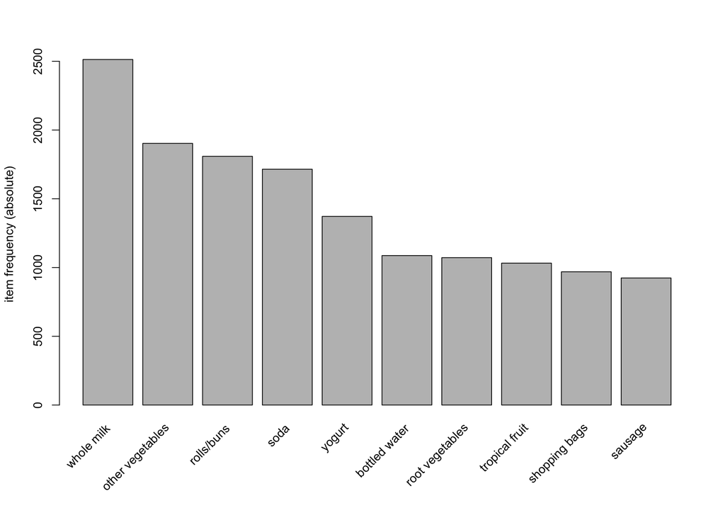

```r
itemFrequencyPlot(Groceries, topN = 10, type="absolute") # Here we can see the top items that are being bought and here "Whole Milk" is the most bought one
```

```r
percentReach20 <- sum(size(Groceries) >= 20) / length(size(Groceries)); percentReach20 # Gives us decimal form of groceries reaching at least 20 items in a transaction
```

```
## [1] 0.003863752
```

```r
meanTransaction <- mean(size(Groceries)); meanTransaction # Gives us mean number of items in a transaction
```

```
## [1] 4.409456
```

- First we can see that the number of transactions in this data set is 9835 and the number of items is 169.
- We can also see from our plot what the top items bought were. In this case *Whole Milk* was the most bought item.
- We can see that the percentage of transactions that involved at least 20 items was 0.3863752%.
- Lastly, we can see that the average number of items in each transaction is 4.409456.

#### Part B

Find all rules with support > 1% and confidence > 50%.

```r
rules <- apriori(Groceries, parameter = list(supp = 0.01, conf = 0.50))
```

```
## Apriori
##
## Parameter specification:
##  confidence minval smax arem  aval originalSupport maxtime support minlen
##         0.5    0.1    1 none FALSE            TRUE       5    0.01      1
##  maxlen target  ext
##      10  rules TRUE
##
## Algorithmic control:
##  filter tree heap memopt load sort verbose
##     0.1 TRUE TRUE  FALSE TRUE    2    TRUE
##
## Absolute minimum support count: 98
##
## set item appearances ...[0 item(s)] done [0.00s].
## set transactions ...[169 item(s), 9835 transaction(s)] done [0.00s].
## sorting and recoding items ... [88 item(s)] done [0.00s].
## creating transaction tree ... done [0.00s].
## checking subsets of size 1 2 3 4 done [0.00s].
## writing ... [15 rule(s)] done [0.00s].
## creating S4 object  ... done [0.00s].
```

```r
rules # Shows us number of rules exist
```

```
## set of 15 rules
```

```r
inspect(rules) # Looks at all rules
```

```
##      lhs                                       rhs                support
## [1]  {curd, yogurt}                         => {whole milk}       0.01006609
## [2]  {other vegetables, butter}             => {whole milk}       0.01148958
## [3]  {other vegetables, domestic eggs}      => {whole milk}       0.01230300
## [4]  {yogurt, whipped/sour cream}           => {whole milk}       0.01087951
## [5]  {other vegetables, whipped/sour cream} => {whole milk}       0.01464159
## [6]  {pip fruit, other vegetables}          => {whole milk}       0.01352313
## [7]  {citrus fruit, root vegetables}        => {other vegetables} 0.01037112
## [8]  {tropical fruit, root vegetables}      => {other vegetables} 0.01230300
## [9]  {tropical fruit, root vegetables}      => {whole milk}       0.01199797
## [10] {tropical fruit, yogurt}               => {whole milk}       0.01514997
## [11] {root vegetables, yogurt}              => {other vegetables} 0.01291307
## [12] {root vegetables, yogurt}              => {whole milk}       0.01453991
## [13] {root vegetables, rolls/buns}          => {other vegetables} 0.01220132
## [14] {root vegetables, rolls/buns}          => {whole milk}       0.01270971
```

[output cut: 17 more lines]

```r
# Find the highest confidence rule
highConfidence <- sort(rules, by = "confidence", decreasing = T)
inspect(highConfidence); inspect(highConfidence[1]) # Shows highest one
```

```
##      lhs                                       rhs                support
## [1]  {citrus fruit, root vegetables}        => {other vegetables} 0.01037112
## [2]  {tropical fruit, root vegetables}      => {other vegetables} 0.01230300
## [3]  {curd, yogurt}                         => {whole milk}       0.01006609
## [4]  {other vegetables, butter}             => {whole milk}       0.01148958
## [5]  {tropical fruit, root vegetables}      => {whole milk}       0.01199797
## [6]  {root vegetables, yogurt}              => {whole milk}       0.01453991
## [7]  {other vegetables, domestic eggs}      => {whole milk}       0.01230300
## [8]  {yogurt, whipped/sour cream}           => {whole milk}       0.01087951
## [9]  {root vegetables, rolls/buns}          => {whole milk}       0.01270971
## [10] {pip fruit, other vegetables}          => {whole milk}       0.01352313
## [11] {tropical fruit, yogurt}               => {whole milk}       0.01514997
## [12] {other vegetables, yogurt}             => {whole milk}       0.02226741
## [13] {other vegetables, whipped/sour cream} => {whole milk}       0.01464159
## [14] {root vegetables, rolls/buns}          => {other vegetables} 0.01220132
```

[output cut: 17 more lines]

```
##     lhs                                rhs                support    confidence
## [1] {citrus fruit, root vegetables} => {other vegetables} 0.01037112 0.5862069
##     coverage   lift     count
## [1] 0.01769192 3.029608 102
```

```r
highConfidence_lhs <- "citrus fruit and root vegetables"
highConfidence_rhs <- "other vegetables"

# Find the highest support rule
highSupport <- sort(rules, by = "support", decreasing = T)
inspect(highSupport); inspect(highSupport[1]) # Shows highest one
```

```
##      lhs                                       rhs                support
## [1]  {other vegetables, yogurt}             => {whole milk}       0.02226741
## [2]  {tropical fruit, yogurt}               => {whole milk}       0.01514997
## [3]  {other vegetables, whipped/sour cream} => {whole milk}       0.01464159
## [4]  {root vegetables, yogurt}              => {whole milk}       0.01453991
## [5]  {pip fruit, other vegetables}          => {whole milk}       0.01352313
## [6]  {root vegetables, yogurt}              => {other vegetables} 0.01291307
## [7]  {root vegetables, rolls/buns}          => {whole milk}       0.01270971
## [8]  {other vegetables, domestic eggs}      => {whole milk}       0.01230300
## [9]  {tropical fruit, root vegetables}      => {other vegetables} 0.01230300
## [10] {root vegetables, rolls/buns}          => {other vegetables} 0.01220132
## [11] {tropical fruit, root vegetables}      => {whole milk}       0.01199797
## [12] {other vegetables, butter}             => {whole milk}       0.01148958
## [13] {yogurt, whipped/sour cream}           => {whole milk}       0.01087951
## [14] {citrus fruit, root vegetables}        => {other vegetables} 0.01037112
```

[output cut: 17 more lines]

```
##     lhs                           rhs          support    confidence coverage
## [1] {other vegetables, yogurt} => {whole milk} 0.02226741 0.5128806  0.04341637
##     lift     count
## [1] 2.007235 219
```

```r
highSupport_lhs <- "other vegetables and yogurt"
highSupport_rhs <- "whole milk"
```

#### Part C

Which items do “whole milk” lead to? find all rules with support > 1%, confidence > 20%, and “whole milk” on the left-hand side. Report these rules.

```r
rulesMilkLeft <- apriori(Groceries,
                         appearance = list(default = "rhs",
                                           lhs = "whole milk"),
                 parameter = list(supp = 0.01,
                                  conf = 0.20))
```

```
## Apriori
##
## Parameter specification:
##  confidence minval smax arem  aval originalSupport maxtime support minlen
##         0.2    0.1    1 none FALSE            TRUE       5    0.01      1
##  maxlen target  ext
##      10  rules TRUE
##
## Algorithmic control:
##  filter tree heap memopt load sort verbose
##     0.1 TRUE TRUE  FALSE TRUE    2    TRUE
##
## Absolute minimum support count: 98
##
## set item appearances ...[1 item(s)] done [0.00s].
## set transactions ...[169 item(s), 9835 transaction(s)] done [0.00s].
## sorting and recoding items ... [88 item(s)] done [0.00s].
## creating transaction tree ... done [0.00s].
## checking subsets of size 1 2 done [0.00s].
## writing ... [3 rule(s)] done [0.00s].
## creating S4 object  ... done [0.00s].
```

```r
inspect(rulesMilkLeft)
```

```
##     lhs             rhs                support    confidence coverage lift
## [1] {whole milk} => {yogurt}           0.05602440 0.2192598  0.255516 1.571735
## [2] {whole milk} => {rolls/buns}       0.05663447 0.2216474  0.255516 1.205032
## [3] {whole milk} => {other vegetables} 0.07483477 0.2928770  0.255516 1.513634
##     count
## [1] 551
## [2] 557
## [3] 736
```

Here from this table created, we can see that knowing that the customer has “whole milk” leads to 3 types of additional purchases. The rules are listed below.

1. Whole Milk leads to Yogurt
2. Whole Milk leads to Rolls/Buns
3. Whole Milk leads to Other Vegetables

#### Part D

Which items lead to “whole milk”? find all rules with support > 1%, confidence > 20%, and “whole milk” on the left-hand side. Report these rules.

```r
rulesMilkRight <- apriori(Groceries,
                         appearance = list(default = "lhs",
                                           rhs = "whole milk"),
                 parameter = list(supp = 0.01,
                                  conf = 0.20))
```

```
## Apriori
##
## Parameter specification:
##  confidence minval smax arem  aval originalSupport maxtime support minlen
##         0.2    0.1    1 none FALSE            TRUE       5    0.01      1
##  maxlen target  ext
##      10  rules TRUE
##
## Algorithmic control:
##  filter tree heap memopt load sort verbose
##     0.1 TRUE TRUE  FALSE TRUE    2    TRUE
##
## Absolute minimum support count: 98
##
## set item appearances ...[1 item(s)] done [0.00s].
## set transactions ...[169 item(s), 9835 transaction(s)] done [0.00s].
## sorting and recoding items ... [88 item(s)] done [0.00s].
## creating transaction tree ... done [0.00s].
## checking subsets of size 1 2 3 4 done [0.00s].
## writing ... [71 rule(s)] done [0.00s].
## creating S4 object  ... done [0.00s].
```

```r
inspect(rulesMilkRight)
```

```
##      lhs                           rhs             support confidence   coverage      lift count
## [1]  {}                         => {whole milk} 0.25551601  0.2555160 1.00000000 1.0000000  2513
## [2]  {hard cheese}              => {whole milk} 0.01006609  0.4107884 0.02450432 1.6076815    99
## [3]  {butter milk}              => {whole milk} 0.01159126  0.4145455 0.02796136 1.6223854   114
## [4]  {ham}                      => {whole milk} 0.01148958  0.4414062 0.02602949 1.7275091   113
## [5]  {sliced cheese}            => {whole milk} 0.01077783  0.4398340 0.02450432 1.7213560   106
## [6]  {oil}                      => {whole milk} 0.01128622  0.4021739 0.02806304 1.5739675   111
## [7]  {onions}                   => {whole milk} 0.01209964  0.3901639 0.03101169 1.5269647   119
## [8]  {berries}                  => {whole milk} 0.01179461  0.3547401 0.03324860 1.3883281   116
## [9]  {hamburger meat}           => {whole milk} 0.01474326  0.4434251 0.03324860 1.7354101   145
## [10] {hygiene articles}         => {whole milk} 0.01281139  0.3888889 0.03294357 1.5219746   126
## [11] {salty snack}              => {whole milk} 0.01118454  0.2956989 0.03782410 1.1572618   110
## [12] {sugar}                    => {whole milk} 0.01504830  0.4444444 0.03385867 1.7393996   148
## [13] {waffles}                  => {whole milk} 0.01270971  0.3306878 0.03843416 1.2941961   125
## [14] {long life bakery product} => {whole milk} 0.01352313  0.3614130 0.03741739 1.4144438   133
```

[output cut: 82 more lines]